# General Additive Models

```r
library(ISLR)
head(Wage)
```

|  | year | age | sex | maritl | race | education | region | jobclass | health | health_ins | logwage | wage |
| --- | --- | --- | --- | --- | --- | --- | --- | --- | --- | --- | --- | --- |
| 231655 | 2006 | 18 | 1. Male | 1. Never Married | 1. White | 1. < HS Grad | 2. Middle Atlantic | 1. Industrial | 1. <=Good | 2. No | 4.318063 | 75.04315 |
| 86582 | 2004 | 24 | 1. Male | 1. Never Married | 1. White | 4. College Grad | 2. Middle Atlantic | 2. Information | 2. >=Very Good | 2. No | 4.255273 | 70.47602 |
| 161300 | 2003 | 45 | 1. Male | 2. Married | 1. White | 3. Some College | 2. Middle Atlantic | 1. Industrial | 1. <=Good | 1. Yes | 4.875061 | 130.98218 |
| 155159 | 2003 | 43 | 1. Male | 2. Married | 3. Asian | 4. College Grad | 2. Middle Atlantic | 2. Information | 2. >=Very Good | 1. Yes | 5.041393 | 154.68529 |
| 11443 | 2005 | 50 | 1. Male | 4. Divorced | 1. White | 2. HS Grad | 2. Middle Atlantic | 2. Information | 1. <=Good | 1. Yes | 4.318063 | 75.04315 |
| 376662 | 2008 | 54 | 1. Male | 2. Married | 1. White | 4. College Grad | 2. Middle Atlantic | 2. Information | 2. >=Very Good | 1. Yes | 4.845098 | 127.11574 |

```r
summary(Wage)
```

```
      year           age               sex                    maritl           race
 Min.   :2003   Min.   :18.00   1. Male  :3000   1. Never Married: 648   1. White:2480
 1st Qu.:2004   1st Qu.:33.75   2. Female:   0   2. Married      :2074   2. Black: 293
 Median :2006   Median :42.00                    3. Widowed      :  19   3. Asian: 190
 Mean   :2006   Mean   :42.41                    4. Divorced     : 204   4. Other:  37
 3rd Qu.:2008   3rd Qu.:51.00                    5. Separated    :  55
 Max.   :2009   Max.   :80.00

              education                     region               jobclass               health      health_ins
 1. < HS Grad      :268   2. Middle Atlantic   :3000   1. Industrial :1544   1. <=Good     : 858   1. Yes:2083
 2. HS Grad        :971   1. New England       :   0   2. Information:1456   2. >=Very Good:2142   2. No : 917
 3. Some College   :650   3. East North Central:   0
 4. College Grad   :685   4. West North Central:   0
 5. Advanced Degree:426   5. South Atlantic    :   0
                          6. East South Central:   0
                          (Other)              :   0
    logwage           wage
 Min.   :3.000   Min.   : 20.09
 1st Qu.:4.447   1st Qu.: 85.38
 Median :4.653   Median :104.92
 Mean   :4.654   Mean   :111.70
 3rd Qu.:4.857   3rd Qu.:128.68
 Max.   :5.763   Max.   :318.34
```

```r
dim(Wage)
```

```
[1] 3000   12
```

We will use GAM to predict wage using natural splines functions of Age, year and taking education as a qualitative predictor.

```r
library(splines)
gam.ns <- lm(wage~ns(age)+ns(year)+education, data = Wage)
summary(gam.ns)
```

```
Call:
lm(formula = wage ~ ns(age) + ns(year) + education, data = Wage)

Residuals:
     Min       1Q   Median       3Q      Max
-113.323  -19.521   -3.964   14.438  219.172

Coefficients:
                            Estimate Std. Error t value Pr(>|t|)
(Intercept)                   67.809      2.715  24.980  < 2e-16 ***
ns(age)                       43.466      4.418   9.838  < 2e-16 ***
ns(year)                       7.905      2.423   3.262  0.00112 **
education2. HS Grad           11.398      2.476   4.603 4.34e-06 ***
education3. Some College      24.234      2.606   9.301  < 2e-16 ***
education4. College Grad      39.741      2.586  15.367  < 2e-16 ***
education5. Advanced Degree   64.854      2.804  23.128  < 2e-16 ***
---
Signif. codes:  0 ‘***’ 0.001 ‘**’ 0.01 ‘*’ 0.05 ‘.’ 0.1 ‘ ’ 1

Residual standard error: 35.89 on 2993 degrees of freedom
Multiple R-squared:  0.2619,    Adjusted R-squared:  0.2604
F-statistic:   177 on 6 and 2993 DF,  p-value: < 2.2e-16
```

To fit general sorts of GAMs, using smoothing splines or other components that can not be expressed in terms of basis functions and then fit using least squares regression, we can use gam library. We fit smoothing spline to age and year with degrees of freedom of 4 and 5 keeping education as it is. For smoothing spline we can use s().

```r
library(gam)
gam1 <- gam(wage ~ s(age, 4) + s(year, 5) + education)
summary(gam1)
```

```
Call: gam(formula = wage ~ s(age, 4) + s(year, 5) + education)
Deviance Residuals:
     Min       1Q   Median       3Q      Max
-119.050  -19.639   -3.361   14.158  213.810

(Dispersion Parameter for gaussian family taken to be 1236.23)

    Null Deviance: 5222086 on 2999 degrees of freedom
Residual Deviance: 3691382 on 2986 degrees of freedom
AIC: 29889.06

Number of Local Scoring Iterations: 2

Anova for Parametric Effects
             Df  Sum Sq Mean Sq F value  Pr(>F)
s(age, 4)     1  200657  200657 162.314 < 2e-16 ***
s(year, 5)    1   21446   21446  17.348 3.2e-05 ***
education     4 1073982  268496 217.189 < 2e-16 ***
Residuals  2986 3691382    1236
---
Signif. codes:  0 ‘***’ 0.001 ‘**’ 0.01 ‘*’ 0.05 ‘.’ 0.1 ‘ ’ 1

Anova for Nonparametric Effects
            Npar Df Npar F  Pr(F)
(Intercept)
s(age, 4)         3 42.317 <2e-16 ***
s(year, 5)        4  1.104 0.3527
education
---
Signif. codes:  0 ‘***’ 0.001 ‘**’ 0.01 ‘*’ 0.05 ‘.’ 0.1 ‘ ’ 1
```

Plot the above fit

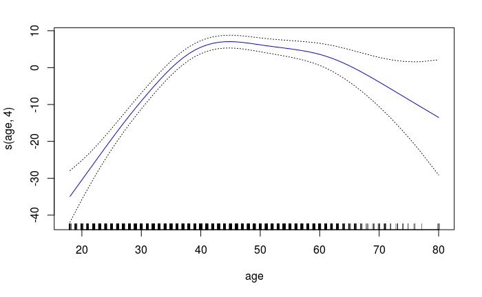

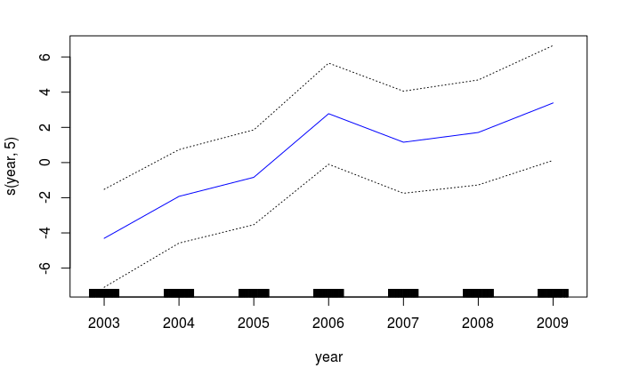

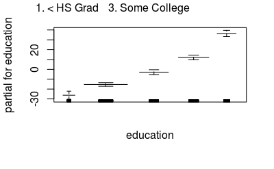

```r
plot(gam1, se = T, col = "blue")
```

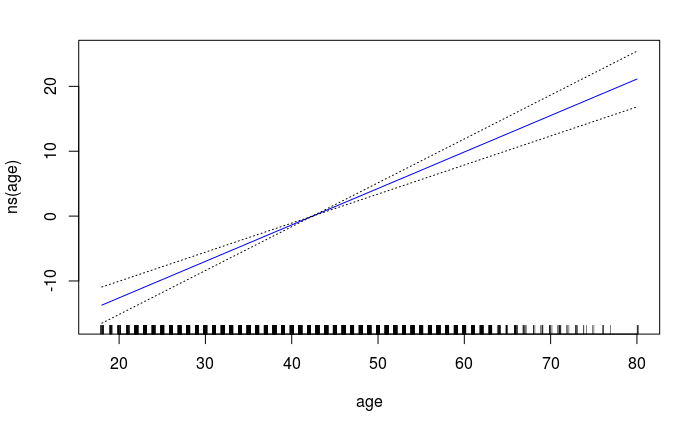

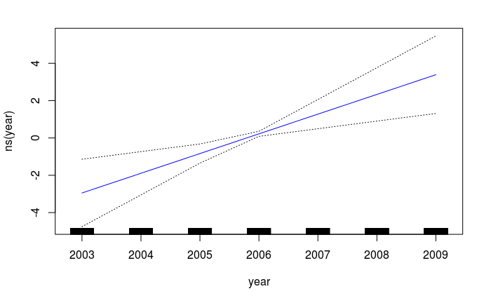

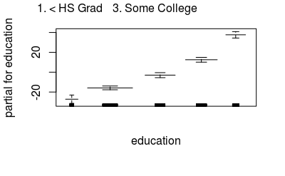

```r
plot.gam(gam.ns, se = T, col = 'blue')
```

Here, the functions of year and age are looking linear.

## ANOVA test. We can use anova test to find out which model is most significant.

Hypothesis Mi is suffiecient and we do not need Mi+1 model

```r
gam2 <- gam(wage ~ year + s(age, 5) + education)
gam3 <- gam(wage ~ s(age, 5) + education)
anova(gam3, gam2, gam1, test = "F")
```

```
Analysis of Deviance Table

Model 1: wage ~ s(age, 5) + education
Model 2: wage ~ year + s(age, 5) + education
Model 3: wage ~ s(age, 4) + s(year, 5) + education
  Resid. Df Resid. Dev     Df Deviance       F    Pr(>F)
1      2990    3711731
2      2989    3693842 1.0000    17889 14.4708 0.0001452 ***
3      2986    3691382 3.0005     2459  0.6629 0.5748351
---
Signif. codes:  0 ‘***’ 0.001 ‘**’ 0.01 ‘*’ 0.05 ‘.’ 0.1 ‘ ’ 1
```

**Otherway**

```r
summary(gam1)
```

```
Call: gam(formula = wage ~ s(age, 4) + s(year, 5) + education)
Deviance Residuals:
     Min       1Q   Median       3Q      Max
-119.050  -19.639   -3.361   14.158  213.810

(Dispersion Parameter for gaussian family taken to be 1236.23)

    Null Deviance: 5222086 on 2999 degrees of freedom
Residual Deviance: 3691382 on 2986 degrees of freedom
AIC: 29889.06

Number of Local Scoring Iterations: 2

Anova for Parametric Effects
             Df  Sum Sq Mean Sq F value  Pr(>F)
s(age, 4)     1  200657  200657 162.314 < 2e-16 ***
s(year, 5)    1   21446   21446  17.348 3.2e-05 ***
education     4 1073982  268496 217.189 < 2e-16 ***
Residuals  2986 3691382    1236
---
Signif. codes:  0 ‘***’ 0.001 ‘**’ 0.01 ‘*’ 0.05 ‘.’ 0.1 ‘ ’ 1

Anova for Nonparametric Effects
            Npar Df Npar F  Pr(F)
(Intercept)
s(age, 4)         3 42.317 <2e-16 ***
s(year, 5)        4  1.104 0.3527
education
---
Signif. codes:  0 ‘***’ 0.001 ‘**’ 0.01 ‘*’ 0.05 ‘.’ 0.1 ‘ ’ 1
```

**Anova for Nonparametric Effects** The p-values for year and age correspond to null hypothesis of a linear relationships vs non linear relationship. The large p-value for year concludes that we dont need non linear function for this term. However, small value of p for age indicates that a non linear function is required.

**Predictions** We can make predictions with model 2.

```r
pred <- predict(gam2, newdata = Wage)
mean((pred - Wage$wage)^2)
```

```
[1] 1231.281
```

## local regression

We can use local regression functions as basis functions in GAM. with **lo()** function.

```r
# I am using GAM 1.14 version
gam4 <- gam(wage~lo(age, span = 0.7)+s(year,df=4)+education, data = Wage)
summary(gam4)
```

```
Call: gam(formula = wage ~ lo(age, span = 0.7) + s(year, df = 4) +
    education, data = Wage)
Deviance Residuals:
     Min       1Q   Median       3Q      Max
-116.997  -19.319   -3.753   14.121  214.445

(Dispersion Parameter for gaussian family taken to be 1243.534)

    Null Deviance: 5222086 on 2999 degrees of freedom
Residual Deviance: 3716672 on 2988.797 degrees of freedom
AIC: 29903.95

Number of Local Scoring Iterations: 2

Anova for Parametric Effects
                        Df  Sum Sq Mean Sq F value    Pr(>F)
lo(age, span = 0.7)    1.0  200675  200675 161.374 < 2.2e-16 ***
s(year, df = 4)        1.0   20050   20050  16.123 6.081e-05 ***
education              4.0 1101825  275456 221.511 < 2.2e-16 ***
Residuals           2988.8 3716672    1244
---
Signif. codes:  0 ‘***’ 0.001 ‘**’ 0.01 ‘*’ 0.05 ‘.’ 0.1 ‘ ’ 1

Anova for Nonparametric Effects
                    Npar Df Npar F  Pr(F)
(Intercept)
lo(age, span = 0.7)     1.2 88.835 <2e-16 ***
s(year, df = 4)         3.0  1.103 0.3464
education
---
Signif. codes:  0 ‘***’ 0.001 ‘**’ 0.01 ‘*’ 0.05 ‘.’ 0.1 ‘ ’ 1
```

**Anova for Nonprametric Effects** Pr value for s(year, df = 4) show that we dont need non linear function for this term.

```r
gam.lo <- gam(wage~lo(year,age,span=0.5)+education)
```

[output not shown]

```r
summary(gam.lo)
```

```
Call: gam(formula = wage ~ lo(year, age, span = 0.5) + education)
Deviance Residuals:
     Min       1Q   Median       3Q      Max
-121.293  -19.659   -3.303   13.911  213.067

(Dispersion Parameter for gaussian family taken to be 1234.897)

    Null Deviance: 5222086 on 2999 degrees of freedom
Residual Deviance: 3688928 on 2987.235 degrees of freedom
AIC: 29884.6

Number of Local Scoring Iterations: 2

Anova for Parametric Effects
                              Df  Sum Sq Mean Sq F value    Pr(>F)
lo(year, age, span = 0.5)    2.0  217479  108740  88.056 < 2.2e-16 ***
education                    4.0 1074786  268696 217.586 < 2.2e-16 ***
Residuals                 2987.2 3688928    1235
---
Signif. codes:  0 ‘***’ 0.001 ‘**’ 0.01 ‘*’ 0.05 ‘.’ 0.1 ‘ ’ 1

Anova for Nonparametric Effects
                          Npar Df Npar F     Pr(F)
(Intercept)
lo(year, age, span = 0.5)     5.8 23.227 < 2.2e-16 ***
education
---
Signif. codes:  0 ‘***’ 0.001 ‘**’ 0.01 ‘*’ 0.05 ‘.’ 0.1 ‘ ’ 1
```

Here. lo(age,year) is an interaction term fit by a local regression surface. We can show the two dimensional surface using akima package.

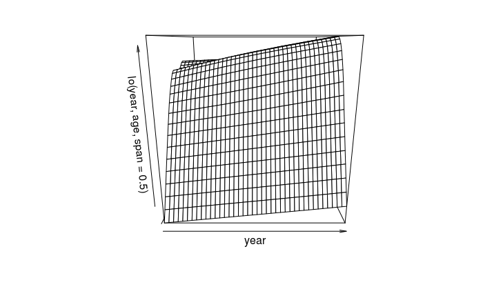

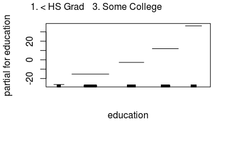

```r
library(akima)
plot(gam.lo)
```

## Logistic Regression:

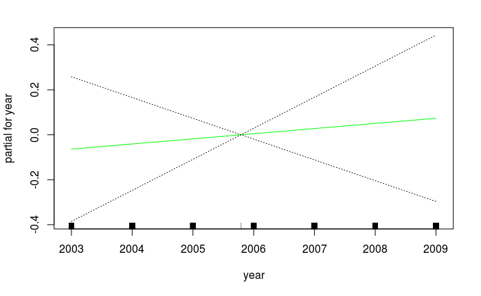

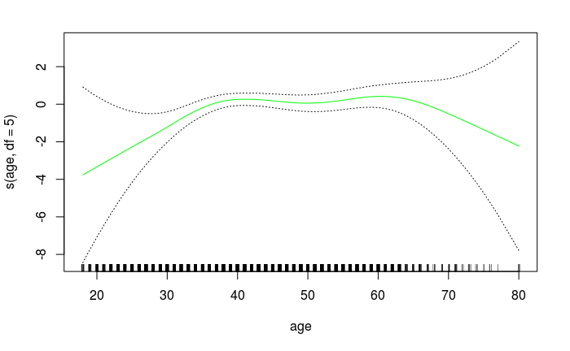

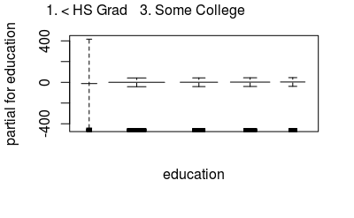

```r
gam.lr <- gam(I(wage>250)~year+s(age, df=5)+education, family = binomial, data = Wage)
plot(gam.lr, col = 'green', se = T)
```

```r
table(education, I(wage>250))
```

```
education            FALSE TRUE
  1. < HS Grad         268    0
  2. HS Grad           966    5
  3. Some College      643    7
  4. College Grad      663   22
  5. Advanced Degree   381   45
```

We will fit logistic regression GAM using all but this category.

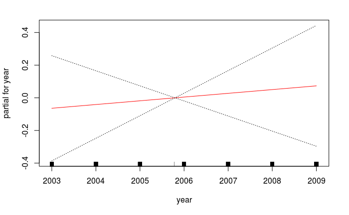

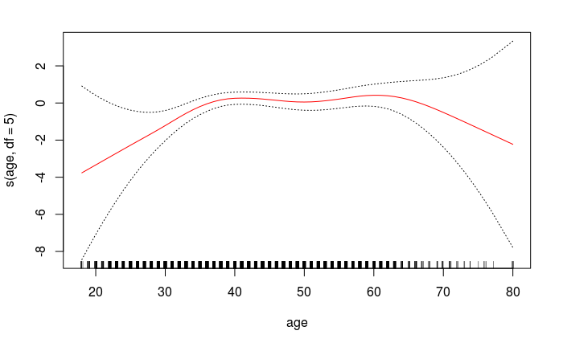

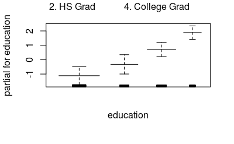

```r
gam.lr <- gam(I(wage>250)~year+s(age, df=5)+education, family = binomial, data = Wage, subset = (education!='1. < HS Grad'))
plot(gam.lr, se = T, col = 'red')
```